# final_analysis

2023-10-25

```r
library(tidyverse)
library(lmerTest)
library(lme4)
library(brms)
library(ggmcmc)
```

```r
library(mcmcplots)
library(rstanarm)
library(RColorBrewer) # needed for some extra colours in one of the graphs
library(bayesplot)
library(ggplot2)
library(dplyr)
library(tidybayes)
library(modelr)
```

```r
dataset = read_csv("./final_study_data_v2.csv",
                   col_types = cols(Condition_ID=col_factor(levels=c("no", "wrong", "correct")),
                                    POS = col_factor(levels = c("Closed","Open")))
                   )
dataset$POS <- factor(dataset$POS)
dataset$Condition_ID <- factor(dataset$Condition_ID)
dataset$Subject_ID <- factor(dataset$Subject_ID)
dataset$Group <- factor(dataset$Group)
dataset$WordToken <- factor(dataset$WordToken)
dataset$Word <- factor(dataset$Word)

sentence_counts <- dataset %>%
  group_by(Subject_ID, Condition_ID) %>%
  summarise(sentences_count = n_distinct(Sentence))
# Calculate the error rate using the formula
error_rates <- sentence_counts %>%
  mutate(error_rate = (12 - sentences_count) / 12)

print(error_rates)
```

```
## # A tibble: 206 × 4
## # Groups:   Subject_ID [69]
##    Subject_ID                       Condition_ID sentences_count error_rate
##    <fct>                            <fct>                  <int>      <dbl>
##  1 0550fec59aa429bf819684811ba0c629 no                        11     0.0833
##  2 0550fec59aa429bf819684811ba0c629 wrong                     12     0
##  3 0550fec59aa429bf819684811ba0c629 correct                   11     0.0833
##  4 078a544f761e8a0bbc852e709f56c929 no                         1     0.917
##  5 078a544f761e8a0bbc852e709f56c929 wrong                      3     0.75
##  6 078a544f761e8a0bbc852e709f56c929 correct                    6     0.5
##  7 0ab6c2cfe511e50cb19c543c6202e45c no                        12     0
##  8 0ab6c2cfe511e50cb19c543c6202e45c wrong                     12     0
##  9 0ab6c2cfe511e50cb19c543c6202e45c correct                   12     0
## 10 0b00fe22c50cc54304bdf38a04eae5f7 no                        12     0
## # ℹ 196 more rows
```

```r
model <- lmer(error_rate ~ Condition_ID + (1|Subject_ID), data = error_rates)
summary(model)
```

```
## Linear mixed model fit by REML. t-tests use Satterthwaite's method [
## lmerModLmerTest]
## Formula: error_rate ~ Condition_ID + (1 | Subject_ID)
##    Data: error_rates
##
## REML criterion at convergence: -161.8
##
## Scaled residuals:
##      Min       1Q   Median       3Q      Max
## -2.73968 -0.53564  0.01341  0.44467  2.70935
##
## Random effects:
##  Groups     Name        Variance Std.Dev.
##  Subject_ID (Intercept) 0.098310 0.31354
##  Residual               0.007058 0.08401
## Number of obs: 206, groups:  Subject_ID, 69
##
## Fixed effects:
##                      Estimate Std. Error        df t value Pr(>|t|)
## (Intercept)         3.063e-02  3.911e-02 7.449e+01   0.783  0.43593
## Condition_IDwrong   4.425e-02  1.438e-02 1.349e+02   3.077  0.00253 **
## Condition_IDcorrect 8.015e-03  1.438e-02 1.349e+02   0.557  0.57822
## ---
## Signif. codes:  0 '***' 0.001 '**' 0.01 '*' 0.05 '.' 0.1 ' ' 1
##
## Correlation of Fixed Effects:
##             (Intr) Cndtn_IDw
## Cndtn_IDwrn -0.186
## Cndtn_IDcrr -0.186  0.505
```

```r
filtered_data11 <- dataset %>% filter(Condition_ID!='wrong')
filtered_data11$Condition_ID <- relevel(filtered_data11$Condition_ID, ref = "correct")
filtered_data11$POS <- relevel(filtered_data11$POS, ref = "Open")
filtered_data11$Condition_ID <- droplevels(filtered_data11$Condition_ID)
contrasts(filtered_data11$Condition_ID) <- "contr.sum"
contrasts(filtered_data11$POS) <- "contr.sum"
```

```r
filtered_data12 <- dataset %>% filter(Condition_ID!='no')
filtered_data12$Condition_ID <- relevel(filtered_data12$Condition_ID, ref = "correct")
filtered_data12$POS <- relevel(filtered_data12$POS, ref = "Open")
filtered_data12$Condition_ID <- droplevels(filtered_data12$Condition_ID)
contrasts(filtered_data12$Condition_ID) <- "contr.sum"
contrasts(filtered_data12$POS) <- "contr.sum"
```

```r
# Seeing the effects of Condition_ID for poorly grounded words to see if there's facilitation.
# Considering slow-downs for correct vs no and correct vs wrong conditions
filtered_data2 <- dataset %>% filter(POS=='Closed')
filtered_data2$POS <- droplevels(filtered_data2$POS)
filtered_data2$Condition_ID <- relevel(filtered_data2$Condition_ID, ref = "correct")
contrasts(filtered_data2$Condition_ID)
```

```
##         no wrong
## correct  0     0
## no       1     0
## wrong    0     1
```

# Analysis With BRMS model

```r
model1_brms = brm(RT ~ Condition_ID*POS + gpt2_surp + Frequency + Length + (Condition_ID*POS + gpt2_surp | Subject_ID) +
              (Condition_ID | Group) + (Condition_ID | Word) + (Condition_ID | WordToken),
              data=filtered_data11, warmup = 1000, iter = 4000,
                          cores = 6, chains = 2, control = list(adapt_delta = 0.85),
                          seed = 123)
```

```
## Trying to compile a simple C file
```

[output not shown]

```r
summary(model1_brms)
```

```
##  Family: gaussian
##   Links: mu = identity; sigma = identity
## Formula: RT ~ Condition_ID * POS + gpt2_surp + Frequency + Length + (Condition_ID * POS + gpt2_surp | Subject_ID) + (Condition_ID | Group) + (Condition_ID | Word) + (Condition_ID | WordToken)
##    Data: filtered_data11 (Number of observations: 18249)
##   Draws: 2 chains, each with iter = 4000; warmup = 1000; thin = 1;
##          total post-warmup draws = 6000
##
## Group-Level Effects:
## ~Group (Number of levels: 108)
##                              Estimate Est.Error l-95% CI u-95% CI Rhat Bulk_ESS
## sd(Intercept)                   39.49      5.74    28.26    51.04 1.00     1807
## sd(Condition_ID1)               24.61      4.57    15.42    33.95 1.00     1830
## cor(Intercept,Condition_ID1)    -0.29      0.22    -0.68     0.17 1.00     1768
##                              Tail_ESS
## sd(Intercept)                    2888
## sd(Condition_ID1)                2018
## cor(Intercept,Condition_ID1)     2798
##
## ~Subject_ID (Number of levels: 69)
##                                       Estimate Est.Error l-95% CI u-95% CI Rhat
## sd(Intercept)                           156.41     14.60   130.62   187.67 1.00
## sd(Condition_ID1)                        15.77      4.22     7.24    24.02 1.00
## sd(POS1)                                 13.82      5.15     3.08    23.82 1.00
## sd(gpt2_surp)                             9.40      1.07     7.46    11.66 1.00
## sd(Condition_ID1:POS1)                   12.85      3.57     6.12    20.23 1.00
## cor(Intercept,Condition_ID1)             -0.34      0.19    -0.69     0.04 1.00
## cor(Intercept,POS1)                      -0.15      0.24    -0.61     0.32 1.00
## cor(Condition_ID1,POS1)                  -0.16      0.31    -0.72     0.48 1.00
## cor(Intercept,gpt2_surp)                  0.61      0.11     0.37     0.80 1.00
## cor(Condition_ID1,gpt2_surp)             -0.13      0.22    -0.57     0.28 1.00
## cor(POS1,gpt2_surp)                       0.06      0.27    -0.43     0.60 1.00
## cor(Intercept,Condition_ID1:POS1)        -0.29      0.21    -0.68     0.14 1.00
## cor(Condition_ID1,Condition_ID1:POS1)     0.33      0.27    -0.25     0.80 1.00
## cor(POS1,Condition_ID1:POS1)             -0.35      0.30    -0.83     0.32 1.00
## cor(gpt2_surp,Condition_ID1:POS1)        -0.60      0.19    -0.89    -0.19 1.00
##                                       Bulk_ESS Tail_ESS
## sd(Intercept)                             1185     2299
## sd(Condition_ID1)                         1919     1567
## sd(POS1)                                  1064      573
## sd(gpt2_surp)                             2229     3738
```

[output cut: 34 more lines]

```
## Intercept            877.95     51.60   776.33   977.63 1.00     1753     3384
## Condition_ID1        -33.25      5.86   -44.18   -21.51 1.00     3401     4378
## POS1                 -31.05     10.43   -51.65   -10.46 1.00     2003     3181
## gpt2_surp             21.79      1.68    18.55    25.11 1.00     1622     2980
## Frequency            -13.68      3.60   -20.72    -6.53 1.00     2354     3310
## Length                 6.28      3.99    -1.40    14.02 1.00     3237     4291
## Condition_ID1:POS1   -17.93      5.06   -27.92    -7.99 1.00     2793     3967
##
## Family Specific Parameters:
##       Estimate Est.Error l-95% CI u-95% CI Rhat Bulk_ESS Tail_ESS
## sigma   316.38      1.78   312.95   319.84 1.00     6800     4516
##
## Draws were sampled using sampling(NUTS). For each parameter, Bulk_ESS
## and Tail_ESS are effective sample size measures, and Rhat is the potential
## scale reduction factor on split chains (at convergence, Rhat = 1).
```

```r
contrasts(filtered_data11$Condition_ID)
```

```
##         [,1]
## correct    1
## no        -1
```

```r
contrasts(filtered_data11$POS)
```

```
##        [,1]
## Open      1
## Closed   -1
```

Down below i am checking the PSRF values from the Gelman-Rubin Diagnostic (using the within and between chain variability). You should look at the Upper CI/Upper limit, which are all should be close to 1.

```r
model1posterior <- as.mcmc(model1_brms)
gelman.diag(model1posterior[, 1:5])
```

```
## Potential scale reduction factors:
##
##                 Point est. Upper C.I.
## b_Intercept           1.01       1.03
## b_Condition_ID1       1.00       1.01
## b_POS1                1.00       1.02
## b_gpt2_surp           1.00       1.00
## b_Frequency           1.00       1.02
##
## Multivariate psrf
##
## 1.01
```

Also plotting the geweke diagnostics to make sure the first and last parts of each chain is below the z-score line

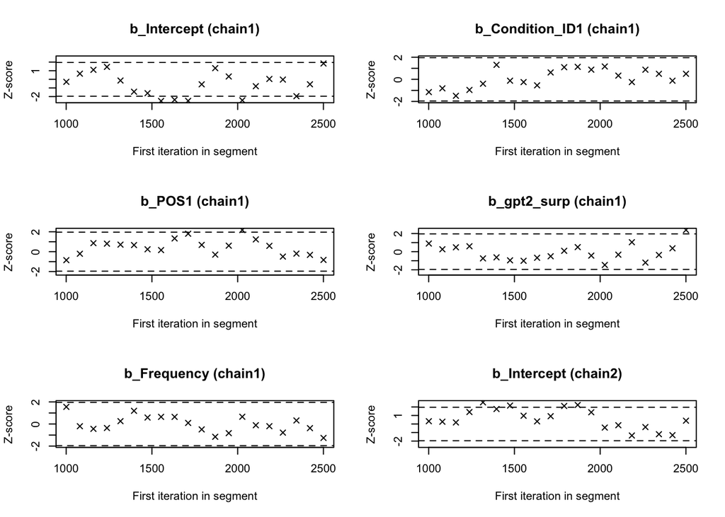

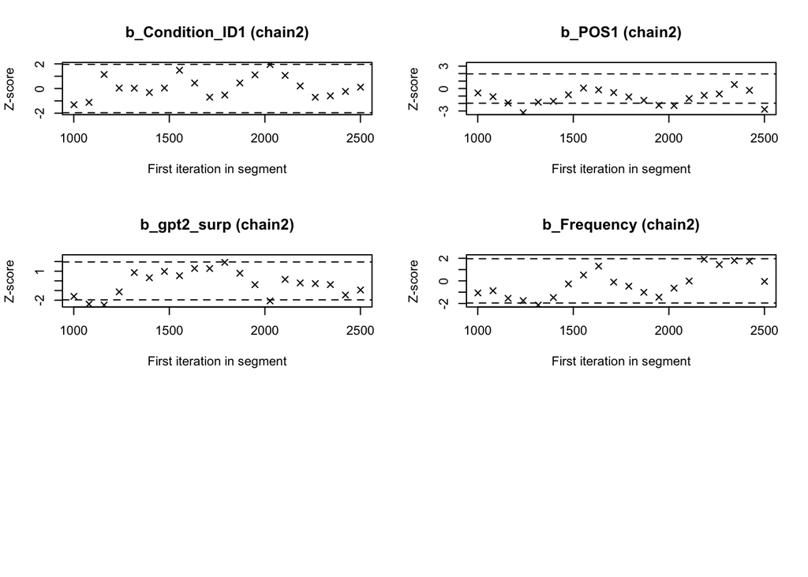

```r
geweke.plot(model1posterior[, 1:5])
```

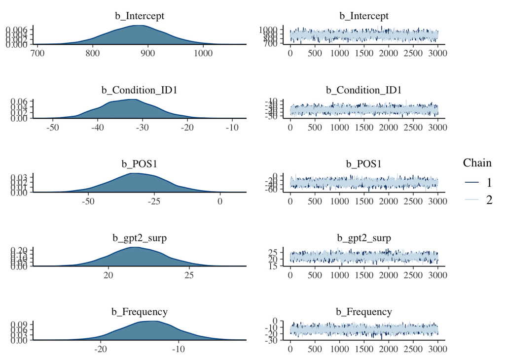

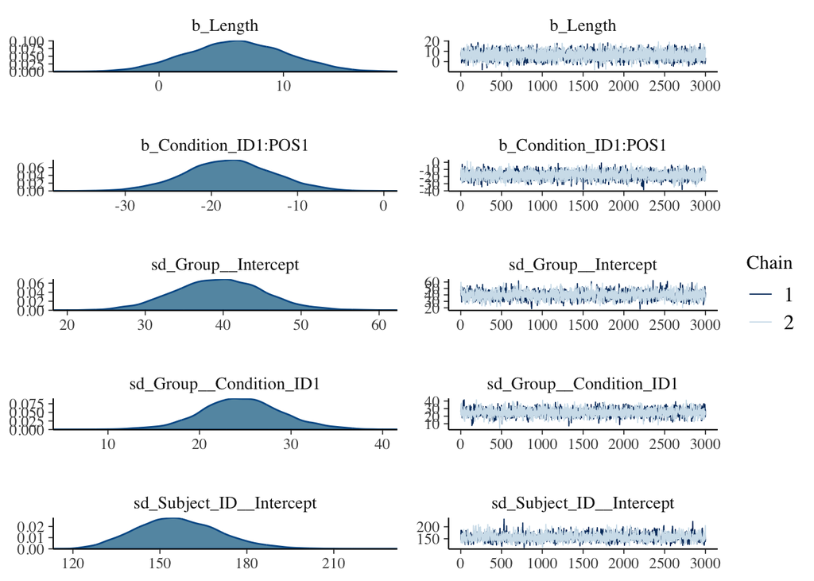

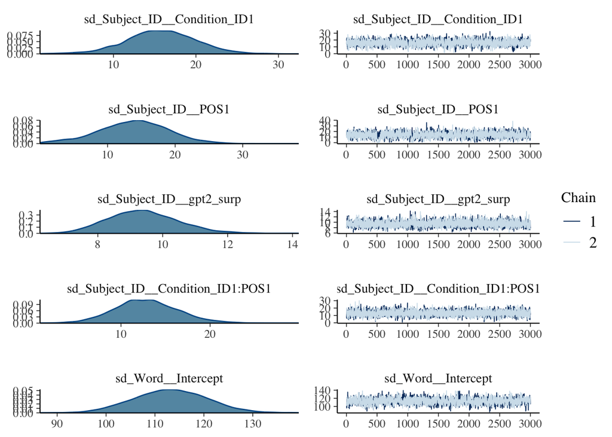

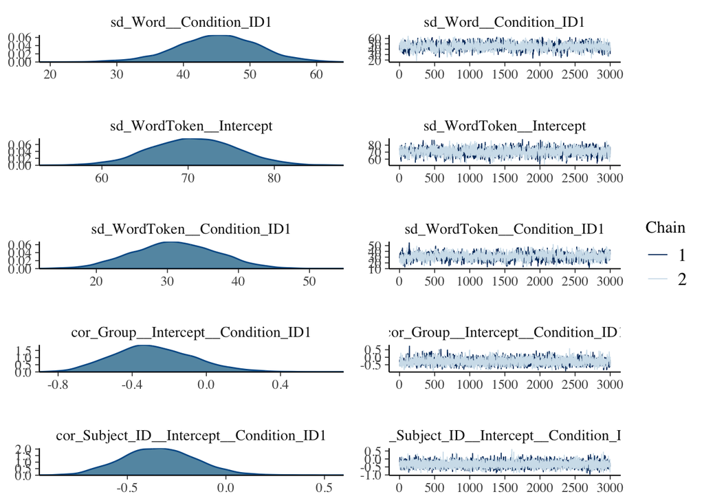

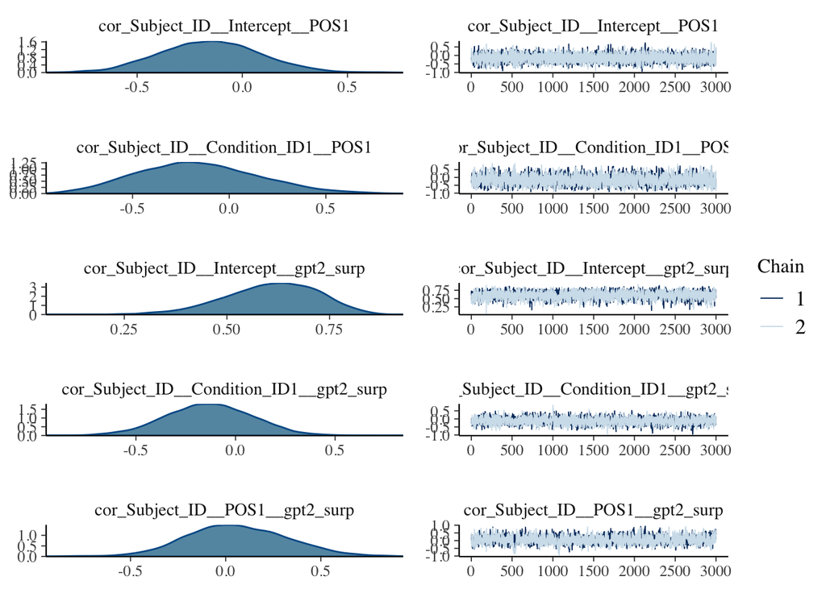

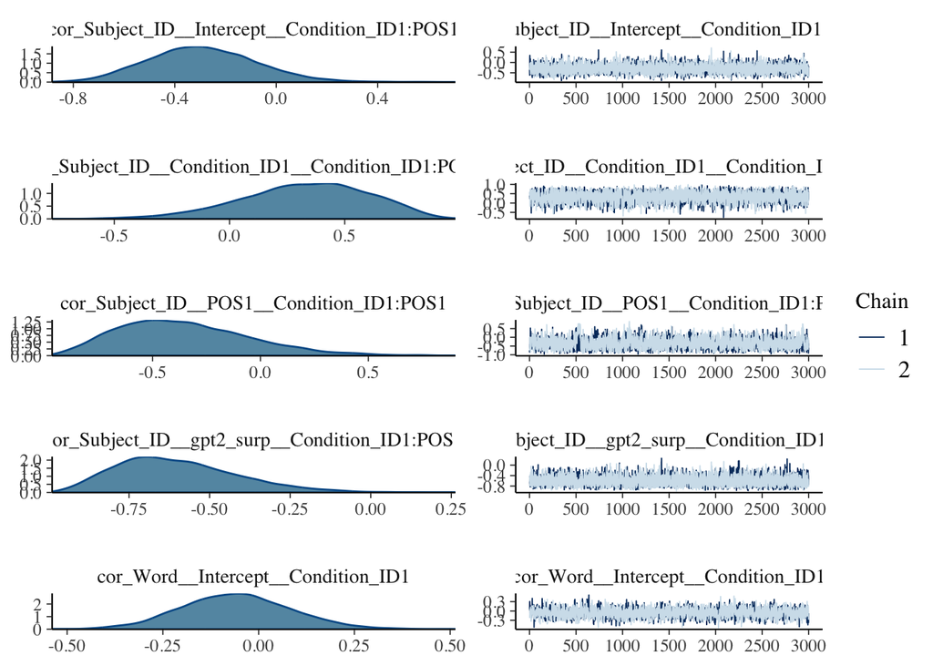

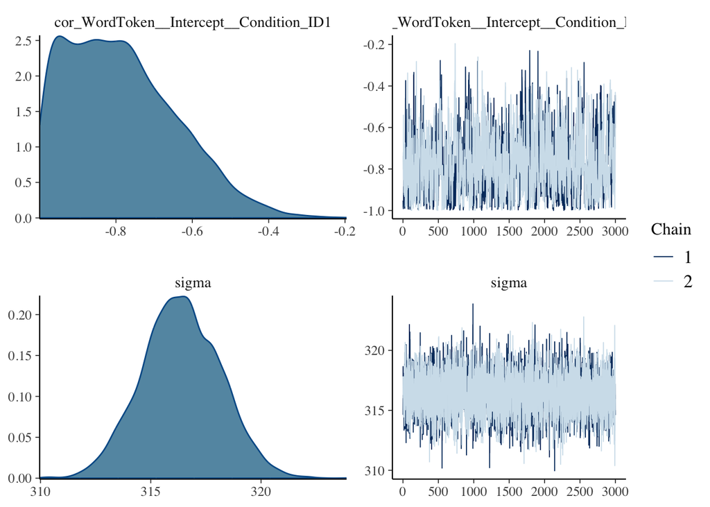

```r
library(bayesplot)
width <- 8
height <- 6  # Height in inches
plot(model1_brms, plotfun = "trace", width=width, height=height)
```

Looks like the chains mixed well, no divergent chains visible in any random or fixed effects We should also look at the pp_check to make sure it makes sense and no further adjustment of prior is needed

```r
pp_check(model1_brms)
```

```
## Using 10 posterior draws for ppc type 'dens_overlay' by default.
```

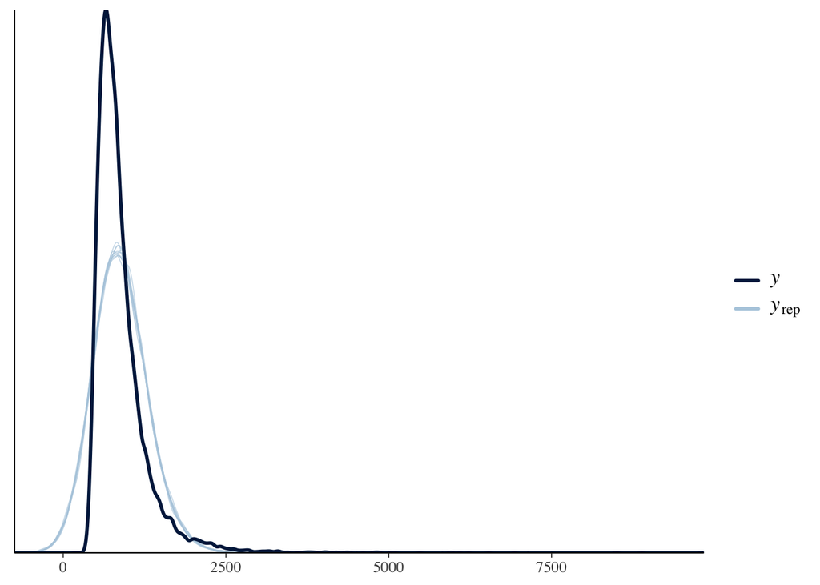

I think it looks okay, the model is acceptable

```r
model1transformed <- ggs(model1_brms) # the ggs function transforms the BRMS output into a longformat tibble, that we can use to make different types of plots.
```

Finally drawing the plots of the posterior distributions to make sure they look normal

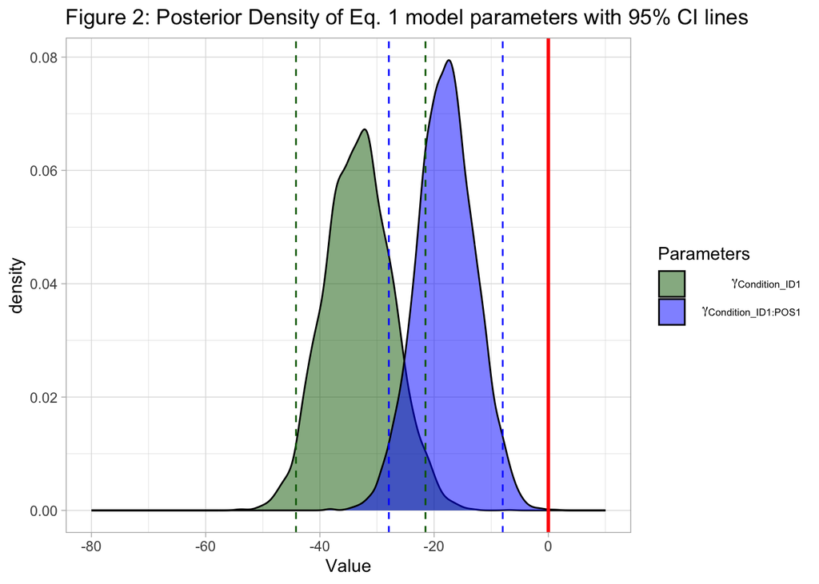

```r
ggplot(filter(model1transformed, Parameter %in% c("b_Condition_ID1","b_Condition_ID1:POS1"),
              Iteration > 1000),
       aes(x    = value,
           fill = Parameter))+
    geom_density(alpha = .5)+
    geom_vline(xintercept = 0,
             col        = "red",
             size       = 1) +
  scale_x_continuous(name   = "Value",
                     limits = c(-80, 10))+

    geom_vline(xintercept = unlist(summary(model1_brms)$fixed[2,3:4]), col = "darkgreen", linetype = 2) +

    geom_vline(xintercept = unlist(summary(model1_brms)$fixed[7,3:4]), col = "blue",       linetype = 2) +
  theme_light()+
   scale_fill_manual(name   =  'Parameters',
                     values = c("darkgreen" , "blue"),
                     labels = c(expression( " "  ~  gamma[Condition_ID1]),
                                expression( " "  ~  gamma[Condition_ID1:POS1])))+
  labs(title = "Figure 2: Posterior Density of Eq. 1 model parameters with 95% CI lines")
```

```r
saveRDS(model1_brms, 'final_11_brms.rds')
```

Repeating the same analysis but with correct vs wrong

```r
model12_brms = brm(RT ~ Condition_ID*POS + gpt2_surp + Frequency + Length + (Condition_ID*POS + gpt2_surp | Subject_ID) +
              (Condition_ID | Group) + (Condition_ID | Word) + (Condition_ID | WordToken),
              data=filtered_data12, warmup = 1000, iter = 4000,
                          cores = 6, chains = 2, control = list(adapt_delta = 0.85),
                          seed = 123)
```

```
## Trying to compile a simple C file
```

[output not shown]

```r
summary(model12_brms)
```

```
##  Family: gaussian
##   Links: mu = identity; sigma = identity
## Formula: RT ~ Condition_ID * POS + gpt2_surp + Frequency + Length + (Condition_ID * POS + gpt2_surp | Subject_ID) + (Condition_ID | Group) + (Condition_ID | Word) + (Condition_ID | WordToken)
##    Data: filtered_data12 (Number of observations: 18055)
##   Draws: 2 chains, each with iter = 4000; warmup = 1000; thin = 1;
##          total post-warmup draws = 6000
##
## Group-Level Effects:
## ~Group (Number of levels: 108)
##                              Estimate Est.Error l-95% CI u-95% CI Rhat Bulk_ESS
## sd(Intercept)                   31.97      6.12    20.17    43.99 1.00     1365
## sd(Condition_ID1)               15.29      7.23     1.32    28.59 1.00      533
## cor(Intercept,Condition_ID1)     0.17      0.38    -0.60     0.89 1.00     1369
##                              Tail_ESS
## sd(Intercept)                    2270
## sd(Condition_ID1)                1084
## cor(Intercept,Condition_ID1)     2176
##
## ~Subject_ID (Number of levels: 69)
##                                       Estimate Est.Error l-95% CI u-95% CI Rhat
## sd(Intercept)                           161.19     15.59   133.94   194.87 1.00
## sd(Condition_ID1)                        30.99      4.16    23.29    39.65 1.00
## sd(POS1)                                 25.19      5.65    14.06    36.27 1.00
## sd(gpt2_surp)                            13.72      1.45    11.17    16.81 1.00
## sd(Condition_ID1:POS1)                   22.41      3.62    15.93    30.03 1.00
## cor(Intercept,Condition_ID1)             -0.33      0.14    -0.57    -0.05 1.00
## cor(Intercept,POS1)                       0.23      0.17    -0.14     0.53 1.00
## cor(Condition_ID1,POS1)                  -0.30      0.20    -0.67     0.10 1.00
## cor(Intercept,gpt2_surp)                  0.31      0.13     0.04     0.55 1.00
## cor(Condition_ID1,gpt2_surp)             -0.37      0.14    -0.63    -0.08 1.00
## cor(POS1,gpt2_surp)                      -0.39      0.16    -0.67    -0.05 1.00
## cor(Intercept,Condition_ID1:POS1)        -0.36      0.15    -0.63    -0.03 1.00
## cor(Condition_ID1,Condition_ID1:POS1)     0.85      0.09     0.64     0.97 1.00
## cor(POS1,Condition_ID1:POS1)             -0.15      0.22    -0.56     0.29 1.00
## cor(gpt2_surp,Condition_ID1:POS1)        -0.61      0.13    -0.83    -0.32 1.00
##                                       Bulk_ESS Tail_ESS
## sd(Intercept)                             1190     1766
## sd(Condition_ID1)                         2783     4062
## sd(POS1)                                  1676     1948
## sd(gpt2_surp)                             2050     3541
```

[output cut: 34 more lines]

```
## Intercept            898.58     52.82   794.15  1003.25 1.00     1698     2830
## Condition_ID1        -48.11      7.81   -63.74   -33.03 1.00     1795     2508
## POS1                 -25.26     11.41   -47.52    -2.58 1.00     1695     2991
## gpt2_surp             22.52      2.08    18.43    26.56 1.00     1996     3650
## Frequency            -14.73      3.76   -22.00    -7.44 1.00     1901     3224
## Length                 5.72      4.13    -2.20    13.95 1.00     2736     3757
## Condition_ID1:POS1   -25.93      7.05   -39.66   -12.34 1.00     1722     3096
##
## Family Specific Parameters:
##       Estimate Est.Error l-95% CI u-95% CI Rhat Bulk_ESS Tail_ESS
## sigma   327.28      1.88   323.58   331.02 1.00     6257     4291
##
## Draws were sampled using sampling(NUTS). For each parameter, Bulk_ESS
## and Tail_ESS are effective sample size measures, and Rhat is the potential
## scale reduction factor on split chains (at convergence, Rhat = 1).
```

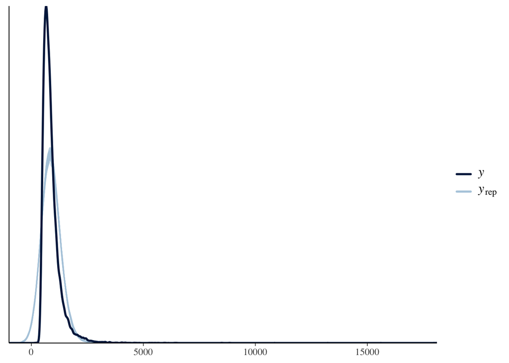

```r
pp_check(model12_brms,ndraws = 100)
```

Here I am trying to explore the third question, if facilitation is still observable for poorly grounded words, or closed class words, using all data from closed-class words

```r
model2_brms = brm(RT ~ Condition_ID + gpt2_surp + Frequency + Length + (Condition_ID + gpt2_surp | Subject_ID)
             + (Condition_ID | Group) + (Condition_ID | Word) + (Condition_ID | WordToken),
             data=filtered_data2,warmup = 1000, iter = 4500,
                          cores = 6, chains = 2, control = list(adapt_delta = 0.85),
                          seed = 123)
```

```
## Trying to compile a simple C file
```

[output not shown]

```r
summary(model2_brms)
```

```
##  Family: gaussian
##   Links: mu = identity; sigma = identity
## Formula: RT ~ Condition_ID + gpt2_surp + Frequency + Length + (Condition_ID + gpt2_surp | Subject_ID) + (Condition_ID | Group) + (Condition_ID | Word) + (Condition_ID | WordToken)
##    Data: filtered_data2 (Number of observations: 12661)
##   Draws: 2 chains, each with iter = 4500; warmup = 1000; thin = 1;
##          total post-warmup draws = 7000
##
## Group-Level Effects:
## ~Group (Number of levels: 108)
##                                       Estimate Est.Error l-95% CI u-95% CI Rhat
## sd(Intercept)                            17.44      8.40     1.65    33.15 1.00
## sd(Condition_IDno)                       36.69     10.93    11.60    56.39 1.00
## sd(Condition_IDwrong)                    21.13      9.64     2.12    39.09 1.00
## cor(Intercept,Condition_IDno)             0.03      0.40    -0.73     0.81 1.00
## cor(Intercept,Condition_IDwrong)          0.22      0.42    -0.62     0.91 1.00
## cor(Condition_IDno,Condition_IDwrong)    -0.18      0.40    -0.88     0.63 1.00
##                                       Bulk_ESS Tail_ESS
## sd(Intercept)                              532      969
## sd(Condition_IDno)                         953      893
## sd(Condition_IDwrong)                      857     1552
## cor(Intercept,Condition_IDno)              773      971
## cor(Intercept,Condition_IDwrong)          1443     2586
## cor(Condition_IDno,Condition_IDwrong)     1990     3523
##
## ~Subject_ID (Number of levels: 69)
##                                       Estimate Est.Error l-95% CI u-95% CI Rhat
## sd(Intercept)                           152.37     14.64   126.57   184.09 1.00
## sd(Condition_IDno)                       25.94     10.91     3.38    46.77 1.00
## sd(Condition_IDwrong)                    10.59      8.00     0.42    30.18 1.00
## sd(gpt2_surp)                            13.44      1.57    10.66    16.80 1.00
## cor(Intercept,Condition_IDno)             0.11      0.26    -0.41     0.61 1.00
## cor(Intercept,Condition_IDwrong)         -0.04      0.39    -0.76     0.74 1.00
## cor(Condition_IDno,Condition_IDwrong)     0.22      0.46    -0.74     0.90 1.00
## cor(Intercept,gpt2_surp)                  0.51      0.12     0.25     0.73 1.00
## cor(Condition_IDno,gpt2_surp)            -0.26      0.27    -0.74     0.34 1.01
## cor(Condition_IDwrong,gpt2_surp)          0.05      0.40    -0.74     0.78 1.01
##                                       Bulk_ESS Tail_ESS
## sd(Intercept)                             1241     2387
## sd(Condition_IDno)                        1030      984
## sd(Condition_IDwrong)                     1431     2664
```

[output cut: 41 more lines]

```
##                   Estimate Est.Error l-95% CI u-95% CI Rhat Bulk_ESS Tail_ESS
## Intercept           952.19    108.48   741.98  1163.07 1.00     2156     3627
## Condition_IDno       30.68     10.74     9.55    52.30 1.00     3970     4560
## Condition_IDwrong    24.82      7.76     9.94    40.52 1.00     4549     4316
## gpt2_surp            30.52      2.70    25.26    35.84 1.00     1959     4471
## Frequency           -21.22      7.10   -35.37    -7.29 1.00     2374     3793
## Length               -0.76      9.03   -18.21    16.76 1.00     2192     3765
##
## Family Specific Parameters:
##       Estimate Est.Error l-95% CI u-95% CI Rhat Bulk_ESS Tail_ESS
## sigma   273.12      1.81   269.55   276.67 1.00     8648     5099
##
## Draws were sampled using sampling(NUTS). For each parameter, Bulk_ESS
## and Tail_ESS are effective sample size measures, and Rhat is the potential
## scale reduction factor on split chains (at convergence, Rhat = 1).
```

```r
model2transformed <- ggs(model2_brms)
```

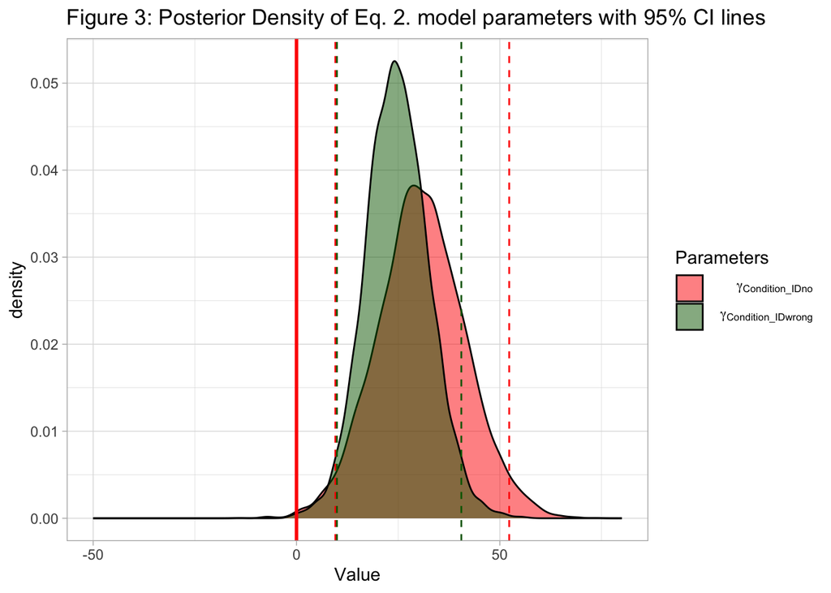

```r
ggplot(filter(model2transformed, Parameter %in% c("b_Condition_IDwrong","b_Condition_IDno"),
              Iteration > 1000),
       aes(x    = value,
           fill = Parameter))+
    geom_density(alpha = .5)+
    geom_vline(xintercept = 0,
             col        = "red",
             size       = 1) +
  scale_x_continuous(name   = "Value",
                     limits = c(-50, 80))+
        geom_vline(xintercept = unlist(summary(model2_brms)$fixed[2,3:4]), col = "red", linetype = 2) +
    geom_vline(xintercept = unlist(summary(model2_brms)$fixed[3,3:4]), col = "darkgreen", linetype = 2) +
  theme_light()+
   scale_fill_manual(name   =  'Parameters',
                     values = c( "red","darkgreen"),
                     labels = c(expression( " "  ~  gamma[Condition_IDno]),
                                expression( " "  ~  gamma[Condition_IDwrong])))+
  labs(title = "Figure 3: Posterior Density of Eq. 2. model parameters with 95% CI lines")
```